# Introduction to Data Visualization and Distributions

Alexander Troynin

25 04 2018

Первый и важный шаг заключается в определении того, как визуализировать данные, какой тип данных мы имеем. На курсе будет два типа, категориальный и числовой. Категорически можно разделить на ординалы и ординалы. А числовые переменные можно разделить на дискретные или непрерывные.

Самая основная статистическая сводка списка объектов или номеров, это его распределение (distribution). Самый простой способ подумать о распределении как компактное описание списка со многими элементами. C категориальными данными распределение просто описывает пропорции каждой уникальной категории. Например, пол, представленный в наборе данных высот можно суммировать по пропорциям каждой из двух категорий, женщины и мужчины.

```r
prop.table(table(heights$sex))
```

```
##
##    Female      Male
## 0.2266667 0.7733333
```

Эта таблица частоты двух категорий является простейшей формой распределения, которое мы можем сформировать. Когда мы имеем больше катешлоий, тогда используем график (bar plot).

Учебники по статистике показывают, что более полезным способом определения распределения для числовых данных является определение функции, которая сообщает долю данных ниже значения A для всех возможных значений A. Эта функция называется кумулятивной функцией распределения (Cumulative distribution function) или CDF.

Если CDF можно определить математически, в отличие от использования данных используется эмпирический CDF (empirical) или ECDF.

Гистограммы намного предпочтительнее, потому что они значительно облегчают ответ на вопросы.

Гистограммы жертвуют лишь небольшим количеством информации для создания сюжетов, которые намного легче интерпретировать. Самый простой способ сделать гистограмму состоит в том, чтобы разделить диапазон наших данных на неперекрывающиеся ящики того же размера. Затем для каждого уровня (each bin) мы подсчитываем количество значений, попадающих в этот интервал.

Плавные графики плотности (Smooth density plots) подобны гистограммам. Преимущество гладких плотностей над гистограммами заключается в том, что это облегчает сравнение с распределением. При правильном аргументе GG-график автоматически отображает пересекающиеся области с разными цветами. Графики гистограммы и плотности обеспечивают отличное резюме распределения.

Если распределение хорошо аппроксимировано по нормальному распределению, мы можем иметь очень полезное и короткое резюме. Но проверить, действительно ли это хорошее приближение, мы можем использовать квантиль-квантильные графики или q-q-графики.

Для получения квантилей для данных мы можем использовать функцию quantile.

```r
x <- heights$height[heights$sex == "Male"]
```

```r
p <- seq(0.05, 0.95, 0.05)

observed_quantiles <- quantile(x, p)
```

Чтобы получить теоретические кванты нормального распределения с соответствующим средним и стандартным отклонением, мы используем функцию qnorm, как это.

```r
theoretical_quantiles <- qnorm( p, mean = mean(x), sd = sd(x))
```

Чтобы убедиться, что они совпадают или нет, мы можем строить их друг против друга, а затем нарисуйте полученную линию, чтобы увидеть, попадают ли точки в линию. Мы можем сделать это, используя функцию plot.

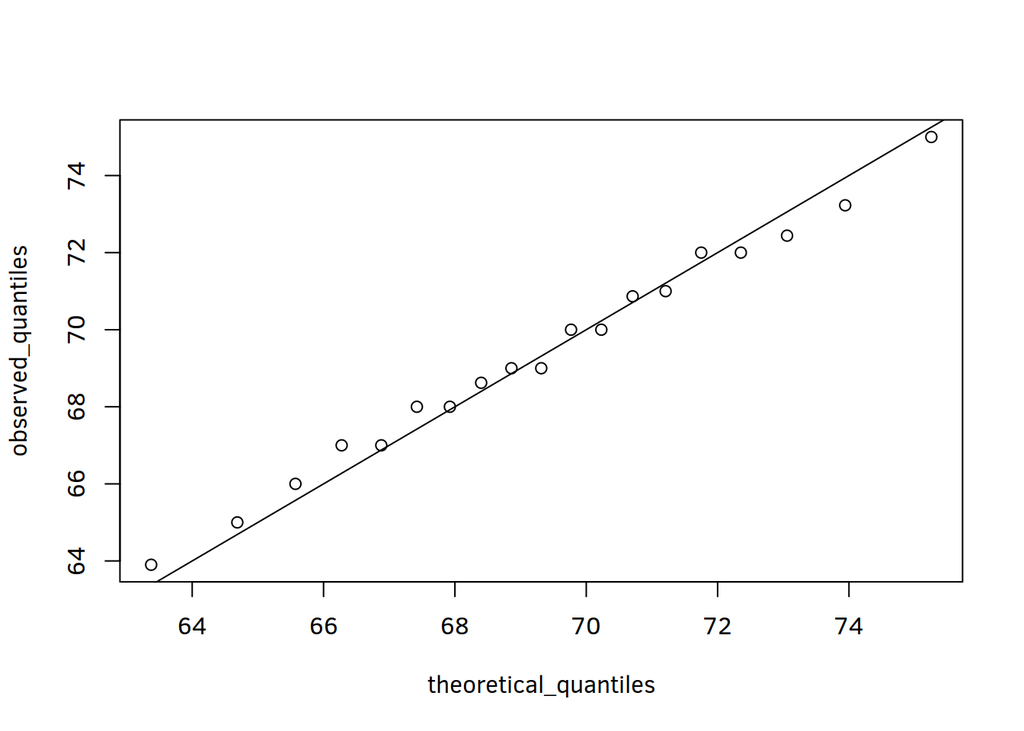

```r
plot(theoretical_quantiles, observed_quantiles)
abline(0,1)
```

Ящик с усами (Boxplot), диаграмма размаха — график, использующийся в описательной статистике, компактно изображающий одномерное распределение вероятностей.

Такой вид диаграммы в удобной форме показывает медиану (или, если нужно, среднее), нижний и верхний квартили, минимальное и максимальное значение выборки и выбросы. Несколько таких ящиков можно нарисовать бок о бок, чтобы визуально сравнивать одно распределение с другим; их можно располагать как горизонтально, так и вертикально. Расстояния между различными частями ящика позволяют определить степень разброса (дисперсии) и асимметрии данных и выявить выбросы.